# Day 1: What statistical distribution to pick?

# What about non-parametric approaches? Where do they fit in?

**1. Limited Modeling Flexibility**

- Nonparametric tests (e.g., Mann–Whitney U, Kruskal–Wallis) are typically designed for simple comparisons. - They do not easily accommodate multiple predictors, interactions, or random effects, which are common in ecological models.

**2. Reduced Statistical Power**

- Nonparametric tests often have lower power than parametric tests when parametric assumptions are reasonably met. - This means a higher chance of Type II errors (failing to detect a true effect).

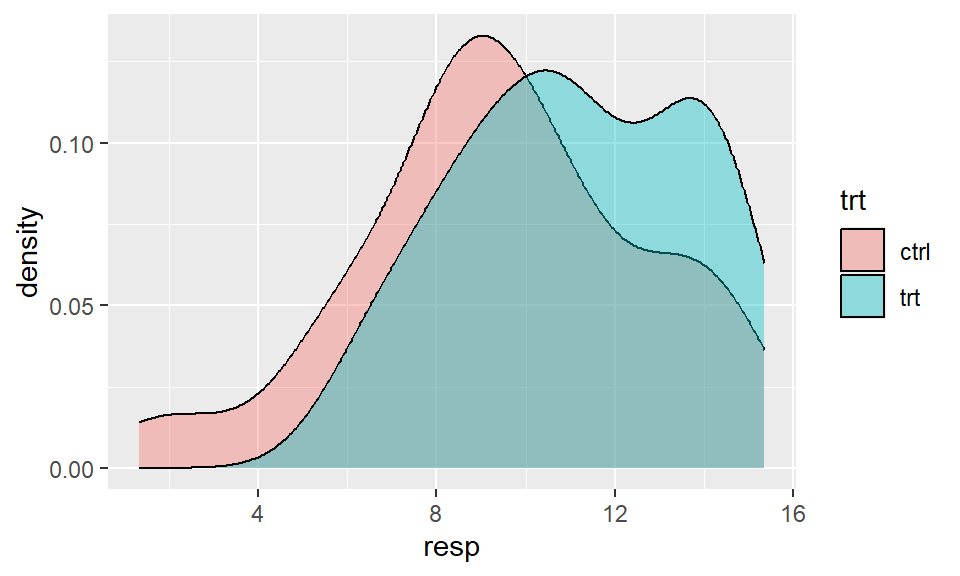

```r
# set up data
  set.seed(20)
  n=40
  makeData<-function(){
   data.frame( trt=rep( c('ctrl','trt'), each=n ),
                    resp=c(rnorm(n,10,3), rnorm(n,11,3)) )
  }
  ds <-makeData()
  ggplot( ds, aes(resp, fill=trt) ) + geom_density(alpha=0.4)
```

```r
  wilcox.test( resp~trt, data=ds)
```

```
    Wilcoxon rank sum exact test

data:  resp by trt
W = 570, p-value = 0.02666
alternative hypothesis: true location shift is not equal to 0
```

```r
  summary(lm(resp~trt, data=ds) )
```

```
Call:
lm(formula = resp ~ trt, data = ds)

Residuals:
    Min      1Q  Median      3Q     Max
-8.1297 -2.0481 -0.0577  2.3324  5.8958

Coefficients:
            Estimate Std. Error t value Pr(>|t|)
(Intercept)   9.4606     0.4667  20.271   <2e-16 ***
trttrt        1.5999     0.6600   2.424   0.0177 *
---
Signif. codes:  0 '***' 0.001 '**' 0.01 '*' 0.05 '.' 0.1 ' ' 1

Residual standard error: 2.952 on 78 degrees of freedom
Multiple R-squared:  0.07006,   Adjusted R-squared:  0.05813
F-statistic: 5.876 on 1 and 78 DF,  p-value: 0.01766
```

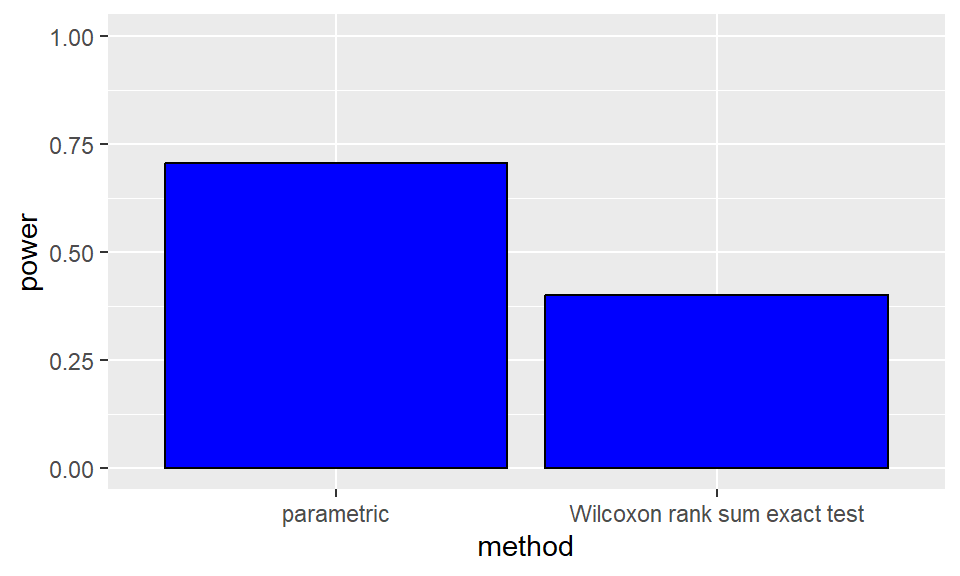

```r
# run tests as nonparametric and parametric and look at power
  runTest <- function(d){
    bind_rows(
      broom::tidy(wilcox.test( resp~trt, data=d)) %>% select(method, p.value),
      broom::tidy(lm(resp~trt, data=d) ) %>% select(p.value) %>% mutate(method='parametric')
    )
    }
  ds_sim <- map_dfr( 1:100,~makeData() %>% mutate(rep=.x) ) %>%
            group_by(rep) %>% nest() %>% mutate( data= map(data, runTest) ) %>%
            unnest('data') %>% mutate(sig= p.value<0.05)
  group_by(ds_sim, method) %>% summarise( power=sum(sig)/n() ) %>%
    ggplot(aes(method, power) ) + geom_col(fill='blue',col='black') +
      scale_y_continuous( labels=scales::percent ) + ylim(0,1)
```

**3. Difficulty Handling Complex Designs**

- Repeated measures, nested data, or hierarchical structures are hard to model with traditional nonparametric tests. - Mixed models or generalized linear models (GLMs/GLMMs) are better suited for such designs.

**4. Interpretation Challenges**

- Nonparametric tests typically assess ranks rather than actual values. - This makes it harder to interpret effect sizes or make predictions based on model coefficients.

**5. Limited Diagnostic Tools**

- Parametric models offer rich diagnostics (e.g., residual plots, AIC/BIC, goodness-of-fit). - Nonparametric tests lack these tools, making it harder to assess model adequacy.

**6. Assumption of Independence**

- Many nonparametric tests assume independent observations. - Violations (e.g., spatial or temporal autocorrelation) can lead to misleading results.

**7. No Direct Extensions to Multivariate Data**

- Nonparametric tests are not easily extended to multivariate or multilevel data structures. - Techniques like PERMANOVA exist but have their own limitations and assumptions.

The adoption of parameteric distribution into multivariate methods replacing non-parametric methods. Dave Warton (UNSW) has done a lot in this space, such as [mvabund](https://www.youtube.com/watch?v=KnPkH6d89l4) and more recent [gllvm](https://jenniniku.github.io/gllvm/)

[figure not shown]